# Risk Factor Analysis

## Outcome Variable

**Outcome Variable:** pers_wast

## Predictor Variables

**Intervention Variable:** parity

**Adjustment Set:**

- arm
- W_mage
- meducyrs
- feducyrs
- hhwealth_quart
- W_mhtcm
- vagbrth
- W_nrooms
- impsan
- delta_W_mage
- delta_meducyrs
- delta_feducyrs
- delta_hhwealth_quart
- delta_W_mhtcm
- delta_vagbrth
- delta_W_nrooms
- delta_impsan

## Stratifying Variables

The analysis was stratified on these variable(s):

- agecat
- studyid
- country

## Data Summary

| agecat | studyid | country | parity | pers_wast | n_cell | n |
| --- | --- | --- | --- | --- | --- | --- |
| 0-24 months | ki1000304b-SAS-CompFeed | INDIA | 1 | 0 | 378 | 1366 |
| 0-24 months | ki1000304b-SAS-CompFeed | INDIA | 1 | 1 | 30 | 1366 |
| 0-24 months | ki1000304b-SAS-CompFeed | INDIA | 2 | 0 | 291 | 1366 |
| 0-24 months | ki1000304b-SAS-CompFeed | INDIA | 2 | 1 | 27 | 1366 |
| 0-24 months | ki1000304b-SAS-CompFeed | INDIA | 3+ | 0 | 583 | 1366 |
| 0-24 months | ki1000304b-SAS-CompFeed | INDIA | 3+ | 1 | 57 | 1366 |
| 0-24 months | ki1000304b-SAS-FoodSuppl | INDIA | 1 | 0 | 62 | 373 |
| 0-24 months | ki1000304b-SAS-FoodSuppl | INDIA | 1 | 1 | 7 | 373 |
| 0-24 months | ki1000304b-SAS-FoodSuppl | INDIA | 2 | 0 | 76 | 373 |
| 0-24 months | ki1000304b-SAS-FoodSuppl | INDIA | 2 | 1 | 11 | 373 |
| 0-24 months | ki1000304b-SAS-FoodSuppl | INDIA | 3+ | 0 | 171 | 373 |
| 0-24 months | ki1000304b-SAS-FoodSuppl | INDIA | 3+ | 1 | 46 | 373 |
| 0-24 months | ki1017093b-PROVIDE | BANGLADESH | 1 | 0 | 237 | 640 |
| 0-24 months | ki1017093b-PROVIDE | BANGLADESH | 1 | 1 | 4 | 640 |
| 0-24 months | ki1017093b-PROVIDE | BANGLADESH | 2 | 0 | 223 | 640 |
| 0-24 months | ki1017093b-PROVIDE | BANGLADESH | 2 | 1 | 4 | 640 |
| 0-24 months | ki1017093b-PROVIDE | BANGLADESH | 3+ | 0 | 165 | 640 |
| 0-24 months | ki1017093b-PROVIDE | BANGLADESH | 3+ | 1 | 7 | 640 |
| 0-24 months | ki1066203-TanzaniaChild2 | TANZANIA, UNITED REPUBLIC OF | 1 | 0 | 710 | 2132 |
| 0-24 months | ki1066203-TanzaniaChild2 | TANZANIA, UNITED REPUBLIC OF | 1 | 1 | 18 | 2132 |
| 0-24 months | ki1066203-TanzaniaChild2 | TANZANIA, UNITED REPUBLIC OF | 2 | 0 | 683 | 2132 |
| 0-24 months | ki1066203-TanzaniaChild2 | TANZANIA, UNITED REPUBLIC OF | 2 | 1 | 20 | 2132 |
| 0-24 months | ki1066203-TanzaniaChild2 | TANZANIA, UNITED REPUBLIC OF | 3+ | 0 | 682 | 2132 |
| 0-24 months | ki1066203-TanzaniaChild2 | TANZANIA, UNITED REPUBLIC OF | 3+ | 1 | 19 | 2132 |
| 0-24 months | ki1101329-Keneba | GAMBIA | 1 | 0 | 220 | 1850 |
| 0-24 months | ki1101329-Keneba | GAMBIA | 1 | 1 | 9 | 1850 |
| 0-24 months | ki1101329-Keneba | GAMBIA | 2 | 0 | 190 | 1850 |
| 0-24 months | ki1101329-Keneba | GAMBIA | 2 | 1 | 9 | 1850 |
| 0-24 months | ki1101329-Keneba | GAMBIA | 3+ | 0 | 1350 | 1850 |
| 0-24 months | ki1101329-Keneba | GAMBIA | 3+ | 1 | 72 | 1850 |

[output cut: 114 more lines]

The following strata were considered:

- agecat: 0-24 months, studyid: ki1000304b-SAS-CompFeed, country: INDIA
- agecat: 0-24 months, studyid: ki1000304b-SAS-FoodSuppl, country: INDIA
- agecat: 0-24 months, studyid: ki1017093b-PROVIDE, country: BANGLADESH
- agecat: 0-24 months, studyid: ki1066203-TanzaniaChild2, country: TANZANIA, UNITED REPUBLIC OF
- agecat: 0-24 months, studyid: ki1101329-Keneba, country: GAMBIA
- agecat: 0-24 months, studyid: ki1113344-GMS-Nepal, country: NEPAL
- agecat: 0-24 months, studyid: ki1126311-ZVITAMBO, country: ZIMBABWE
- agecat: 0-24 months, studyid: ki1135781-COHORTS, country: GUATEMALA
- agecat: 0-24 months, studyid: ki1135781-COHORTS, country: INDIA
- agecat: 0-24 months, studyid: ki1135781-COHORTS, country: PHILIPPINES
- agecat: 0-24 months, studyid: kiGH5241-JiVitA-3, country: BANGLADESH
- agecat: 0-6 months, studyid: ki1017093b-PROVIDE, country: BANGLADESH
- agecat: 0-6 months, studyid: ki1066203-TanzaniaChild2, country: TANZANIA, UNITED REPUBLIC OF
- agecat: 0-6 months, studyid: ki1101329-Keneba, country: GAMBIA
- agecat: 0-6 months, studyid: ki1113344-GMS-Nepal, country: NEPAL
- agecat: 6-24 months, studyid: ki1000304b-SAS-CompFeed, country: INDIA
- agecat: 6-24 months, studyid: ki1000304b-SAS-FoodSuppl, country: INDIA
- agecat: 6-24 months, studyid: ki1017093b-PROVIDE, country: BANGLADESH
- agecat: 6-24 months, studyid: ki1066203-TanzaniaChild2, country: TANZANIA, UNITED REPUBLIC OF
- agecat: 6-24 months, studyid: ki1101329-Keneba, country: GAMBIA
- agecat: 6-24 months, studyid: ki1113344-GMS-Nepal, country: NEPAL
- agecat: 6-24 months, studyid: ki1126311-ZVITAMBO, country: ZIMBABWE
- agecat: 6-24 months, studyid: ki1135781-COHORTS, country: GUATEMALA
- agecat: 6-24 months, studyid: ki1135781-COHORTS, country: PHILIPPINES

### Dropped Strata

Some strata were dropped due to rare outcomes:

- agecat: 0-24 months, studyid: ki1017093b-PROVIDE, country: BANGLADESH
- agecat: 0-24 months, studyid: ki1135781-COHORTS, country: GUATEMALA
- agecat: 0-6 months, studyid: ki1017093b-PROVIDE, country: BANGLADESH
- agecat: 0-6 months, studyid: ki1101329-Keneba, country: GAMBIA
- agecat: 6-24 months, studyid: ki1135781-COHORTS, country: GUATEMALA

## Methods Detail

We’re interested in the causal parameters $E[Y_a]$ for all values of $a \in \mathcal{A}$. These parameters represent the mean outcome if, possibly contrary to fact, we intervened to set all units to have $A=a$. Under the randomization and positivity assumptions, these are identified by the statistical parameters $\psi_a=E_W[E_{Y|A,W}(Y|A=a,W)]$. In addition, we’re interested in the mean of $Y$, $E[Y]$ under no intervention (the observed mean). We will estimate these parameters by using SuperLearner to fit the relevant likelihood factors – $E_{Y|A,W}(Y|A=a,W)$ and $p(A=a|W)$, and then updating our likelihood fit using a joint TMLE.

For unadjusted analyses ($W=\{\}$), initial likelihoods were estimated using Lrnr_glm to estimate the simple $E(Y|A)$ and Lrnr_mean to estimate $p(A)$. For adjusted analyses, a small library containing Lrnr_glmnet, Lrnr_xgboost, and Lrnr_mean was used.

Having estimated these parameters, we will then use the delta method to estimate relative risks and attributable risks relative to a prespecified baseline level of $A$.

# Results Detail

## Results Plots

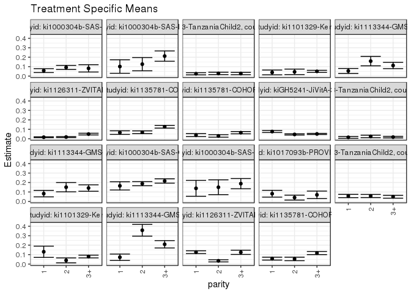

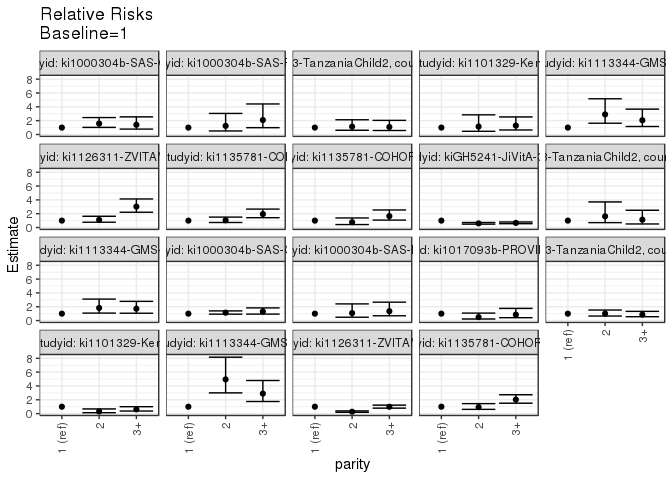

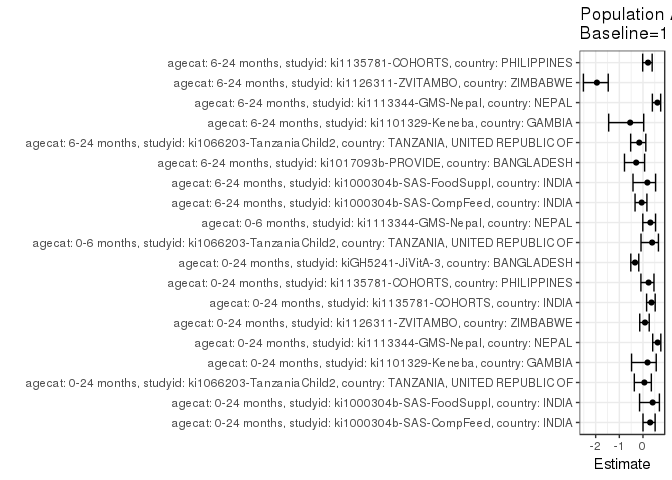

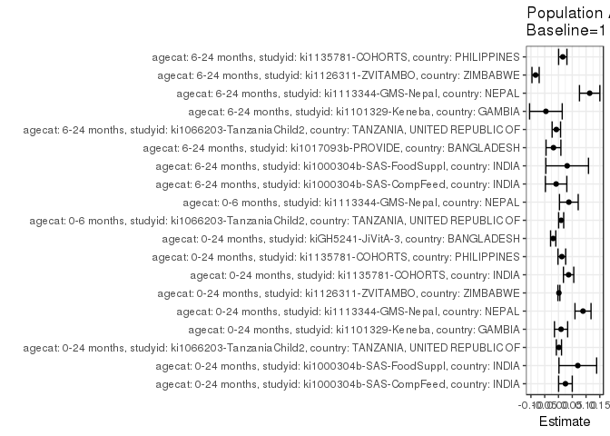

## Results Table

### Parameter: TSM

| agecat | studyid | country | intervention_level | baseline_level | estimate | ci_lower | ci_upper |
| --- | --- | --- | --- | --- | --- | --- | --- |
| 0-24 months | ki1000304b-SAS-CompFeed | INDIA | 1 | NA | 0.0581747 | 0.0377476 | 0.0786018 |
| 0-24 months | ki1000304b-SAS-CompFeed | INDIA | 2 | NA | 0.0921511 | 0.0703974 | 0.1139048 |
| 0-24 months | ki1000304b-SAS-CompFeed | INDIA | 3+ | NA | 0.0820930 | 0.0435669 | 0.1206191 |
| 0-24 months | ki1000304b-SAS-FoodSuppl | INDIA | 1 | NA | 0.1014493 | 0.0301143 | 0.1727842 |
| 0-24 months | ki1000304b-SAS-FoodSuppl | INDIA | 2 | NA | 0.1264368 | 0.0565081 | 0.1963655 |
| 0-24 months | ki1000304b-SAS-FoodSuppl | INDIA | 3+ | NA | 0.2119816 | 0.1575290 | 0.2664341 |
| 0-24 months | ki1066203-TanzaniaChild2 | TANZANIA, UNITED REPUBLIC OF | 1 | NA | 0.0251312 | 0.0137773 | 0.0364851 |
| 0-24 months | ki1066203-TanzaniaChild2 | TANZANIA, UNITED REPUBLIC OF | 2 | NA | 0.0287391 | 0.0163925 | 0.0410858 |
| 0-24 months | ki1066203-TanzaniaChild2 | TANZANIA, UNITED REPUBLIC OF | 3+ | NA | 0.0273444 | 0.0152824 | 0.0394065 |
| 0-24 months | ki1101329-Keneba | GAMBIA | 1 | NA | 0.0393013 | 0.0141277 | 0.0644749 |
| 0-24 months | ki1101329-Keneba | GAMBIA | 2 | NA | 0.0452261 | 0.0163470 | 0.0741053 |
| 0-24 months | ki1101329-Keneba | GAMBIA | 3+ | NA | 0.0506329 | 0.0392344 | 0.0620315 |
| 0-24 months | ki1113344-GMS-Nepal | NEPAL | 1 | NA | 0.0545954 | 0.0281266 | 0.0810642 |
| 0-24 months | ki1113344-GMS-Nepal | NEPAL | 2 | NA | 0.1585642 | 0.1088471 | 0.2082812 |
| 0-24 months | ki1113344-GMS-Nepal | NEPAL | 3+ | NA | 0.1126259 | 0.0790079 | 0.1462439 |
| 0-24 months | ki1126311-ZVITAMBO | ZIMBABWE | 1 | NA | 0.0163776 | 0.0122605 | 0.0204947 |
| 0-24 months | ki1126311-ZVITAMBO | ZIMBABWE | 2 | NA | 0.0183267 | 0.0131781 | 0.0234753 |
| 0-24 months | ki1126311-ZVITAMBO | ZIMBABWE | 3+ | NA | 0.0494829 | 0.0402768 | 0.0586889 |
| 0-24 months | ki1135781-COHORTS | INDIA | 1 | NA | 0.0653647 | 0.0462845 | 0.0844448 |
| 0-24 months | ki1135781-COHORTS | INDIA | 2 | NA | 0.0686909 | 0.0538302 | 0.0835517 |
| 0-24 months | ki1135781-COHORTS | INDIA | 3+ | NA | 0.1273560 | 0.1129231 | 0.1417890 |
| 0-24 months | ki1135781-COHORTS | PHILIPPINES | 1 | NA | 0.0390746 | 0.0239098 | 0.0542394 |
| 0-24 months | ki1135781-COHORTS | PHILIPPINES | 2 | NA | 0.0300903 | 0.0168349 | 0.0433457 |
| 0-24 months | ki1135781-COHORTS | PHILIPPINES | 3+ | NA | 0.0645370 | 0.0523988 | 0.0766752 |
| 0-24 months | kiGH5241-JiVitA-3 | BANGLADESH | 1 | NA | 0.0764560 | 0.0660424 | 0.0868695 |
| 0-24 months | kiGH5241-JiVitA-3 | BANGLADESH | 2 | NA | 0.0459872 | 0.0394912 | 0.0524832 |
| 0-24 months | kiGH5241-JiVitA-3 | BANGLADESH | 3+ | NA | 0.0511879 | 0.0451680 | 0.0572077 |
| 0-6 months | ki1066203-TanzaniaChild2 | TANZANIA, UNITED REPUBLIC OF | 1 | NA | 0.0153928 | 0.0056818 | 0.0251038 |
| 0-6 months | ki1066203-TanzaniaChild2 | TANZANIA, UNITED REPUBLIC OF | 2 | NA | 0.0249343 | 0.0116291 | 0.0382395 |
| 0-6 months | ki1066203-TanzaniaChild2 | TANZANIA, UNITED REPUBLIC OF | 3+ | NA | 0.0175207 | 0.0093348 | 0.0257067 |
| 0-6 months | ki1113344-GMS-Nepal | NEPAL | 1 | NA | 0.0823395 | 0.0481636 | 0.1165153 |
| 0-6 months | ki1113344-GMS-Nepal | NEPAL | 2 | NA | 0.1506808 | 0.1015732 | 0.1997885 |
| 0-6 months | ki1113344-GMS-Nepal | NEPAL | 3+ | NA | 0.1415887 | 0.1076533 | 0.1755241 |
| 6-24 months | ki1000304b-SAS-CompFeed | INDIA | 1 | NA | 0.1647088 | 0.1210396 | 0.2083780 |
| 6-24 months | ki1000304b-SAS-CompFeed | INDIA | 2 | NA | 0.1878990 | 0.1661600 | 0.2096380 |
| 6-24 months | ki1000304b-SAS-CompFeed | INDIA | 3+ | NA | 0.2161768 | 0.1931245 | 0.2392290 |
| 6-24 months | ki1000304b-SAS-FoodSuppl | INDIA | 1 | NA | 0.1384615 | 0.0543763 | 0.2225468 |
| 6-24 months | ki1000304b-SAS-FoodSuppl | INDIA | 2 | NA | 0.1500000 | 0.0716417 | 0.2283583 |
| 6-24 months | ki1000304b-SAS-FoodSuppl | INDIA | 3+ | NA | 0.1881188 | 0.1341477 | 0.2420899 |
| 6-24 months | ki1017093b-PROVIDE | BANGLADESH | 1 | NA | 0.0814480 | 0.0453564 | 0.1175395 |
| 6-24 months | ki1017093b-PROVIDE | BANGLADESH | 2 | NA | 0.0405405 | 0.0145754 | 0.0665057 |
| 6-24 months | ki1017093b-PROVIDE | BANGLADESH | 3+ | NA | 0.0696203 | 0.0299030 | 0.1093375 |
| 6-24 months | ki1066203-TanzaniaChild2 | TANZANIA, UNITED REPUBLIC OF | 1 | NA | 0.0572556 | 0.0399290 | 0.0745822 |
| 6-24 months | ki1066203-TanzaniaChild2 | TANZANIA, UNITED REPUBLIC OF | 2 | NA | 0.0572863 | 0.0406094 | 0.0739631 |
| 6-24 months | ki1066203-TanzaniaChild2 | TANZANIA, UNITED REPUBLIC OF | 3+ | NA | 0.0494645 | 0.0342357 | 0.0646934 |
| 6-24 months | ki1101329-Keneba | GAMBIA | 1 | NA | 0.1301025 | 0.0706924 | 0.1895126 |
| 6-24 months | ki1101329-Keneba | GAMBIA | 2 | NA | 0.0392227 | 0.0130860 | 0.0653594 |
| 6-24 months | ki1101329-Keneba | GAMBIA | 3+ | NA | 0.0799175 | 0.0654803 | 0.0943548 |
| 6-24 months | ki1113344-GMS-Nepal | NEPAL | 1 | NA | 0.0722912 | 0.0383907 | 0.1061917 |
| 6-24 months | ki1113344-GMS-Nepal | NEPAL | 2 | NA | 0.3576420 | 0.2955883 | 0.4196956 |
| 6-24 months | ki1113344-GMS-Nepal | NEPAL | 3+ | NA | 0.2093742 | 0.1705396 | 0.2482088 |
| 6-24 months | ki1126311-ZVITAMBO | ZIMBABWE | 1 | NA | 0.1258433 | 0.1112474 | 0.1404392 |
| 6-24 months | ki1126311-ZVITAMBO | ZIMBABWE | 2 | NA | 0.0345596 | 0.0233122 | 0.0458069 |
| 6-24 months | ki1126311-ZVITAMBO | ZIMBABWE | 3+ | NA | 0.1242909 | 0.1018274 | 0.1467544 |
| 6-24 months | ki1135781-COHORTS | PHILIPPINES | 1 | NA | 0.0575441 | 0.0424370 | 0.0726512 |
| 6-24 months | ki1135781-COHORTS | PHILIPPINES | 2 | NA | 0.0543644 | 0.0360739 | 0.0726549 |
| 6-24 months | ki1135781-COHORTS | PHILIPPINES | 3+ | NA | 0.1167417 | 0.1002839 | 0.1331996 |

### Parameter: E(Y)

| agecat | studyid | country | intervention_level | baseline_level | estimate | ci_lower | ci_upper |
| --- | --- | --- | --- | --- | --- | --- | --- |
| 0-24 months | ki1000304b-SAS-CompFeed | INDIA | NA | NA | 0.0834553 | 0.0601989 | 0.1067118 |
| 0-24 months | ki1000304b-SAS-FoodSuppl | INDIA | NA | NA | 0.1715818 | 0.1332696 | 0.2098940 |
| 0-24 months | ki1066203-TanzaniaChild2 | TANZANIA, UNITED REPUBLIC OF | NA | NA | 0.0267355 | 0.0198866 | 0.0335843 |
| 0-24 months | ki1101329-Keneba | GAMBIA | NA | NA | 0.0486486 | 0.0388428 | 0.0584545 |
| 0-24 months | ki1113344-GMS-Nepal | NEPAL | NA | NA | 0.1435811 | 0.1153098 | 0.1718524 |
| 0-24 months | ki1126311-ZVITAMBO | ZIMBABWE | NA | NA | 0.0178954 | 0.0152055 | 0.0205853 |
| 0-24 months | ki1135781-COHORTS | INDIA | NA | NA | 0.1020862 | 0.0921879 | 0.1119845 |
| 0-24 months | ki1135781-COHORTS | PHILIPPINES | NA | NA | 0.0512273 | 0.0430760 | 0.0593786 |
| 0-24 months | kiGH5241-JiVitA-3 | BANGLADESH | NA | NA | 0.0572358 | 0.0531429 | 0.0613287 |
| 0-6 months | ki1066203-TanzaniaChild2 | TANZANIA, UNITED REPUBLIC OF | NA | NA | 0.0251232 | 0.0183136 | 0.0319327 |
| 0-6 months | ki1113344-GMS-Nepal | NEPAL | NA | NA | 0.1199262 | 0.0925504 | 0.1473020 |
| 6-24 months | ki1000304b-SAS-CompFeed | INDIA | NA | NA | 0.1561462 | 0.1410608 | 0.1712315 |
| 6-24 months | ki1000304b-SAS-FoodSuppl | INDIA | NA | NA | 0.1700288 | 0.1304464 | 0.2096113 |
| 6-24 months | ki1017093b-PROVIDE | BANGLADESH | NA | NA | 0.0632280 | 0.0437545 | 0.0827015 |
| 6-24 months | ki1066203-TanzaniaChild2 | TANZANIA, UNITED REPUBLIC OF | NA | NA | 0.0494931 | 0.0391092 | 0.0598771 |
| 6-24 months | ki1101329-Keneba | GAMBIA | NA | NA | 0.0844342 | 0.0713702 | 0.0974983 |
| 6-24 months | ki1113344-GMS-Nepal | NEPAL | NA | NA | 0.1854419 | 0.1537023 | 0.2171816 |
| 6-24 months | ki1126311-ZVITAMBO | ZIMBABWE | NA | NA | 0.0426966 | 0.0342942 | 0.0510990 |
| 6-24 months | ki1135781-COHORTS | PHILIPPINES | NA | NA | 0.0731338 | 0.0631985 | 0.0830690 |

### Parameter: RR

| agecat | studyid | country | intervention_level | baseline_level | estimate | ci_lower | ci_upper |
| --- | --- | --- | --- | --- | --- | --- | --- |
| 0-24 months | ki1000304b-SAS-CompFeed | INDIA | 1 | 1 | 1.0000000 | 1.0000000 | 1.0000000 |
| 0-24 months | ki1000304b-SAS-CompFeed | INDIA | 2 | 1 | 1.5840411 | 1.0256528 | 2.4464285 |
| 0-24 months | ki1000304b-SAS-CompFeed | INDIA | 3+ | 1 | 1.4111464 | 0.7808209 | 2.5503083 |
| 0-24 months | ki1000304b-SAS-FoodSuppl | INDIA | 1 | 1 | 1.0000000 | 1.0000000 | 1.0000000 |
| 0-24 months | ki1000304b-SAS-FoodSuppl | INDIA | 2 | 1 | 1.2463054 | 0.5094502 | 3.0489281 |
| 0-24 months | ki1000304b-SAS-FoodSuppl | INDIA | 3+ | 1 | 2.0895326 | 0.9883986 | 4.4173943 |
| 0-24 months | ki1066203-TanzaniaChild2 | TANZANIA, UNITED REPUBLIC OF | 1 | 1 | 1.0000000 | 1.0000000 | 1.0000000 |
| 0-24 months | ki1066203-TanzaniaChild2 | TANZANIA, UNITED REPUBLIC OF | 2 | 1 | 1.1435633 | 0.6129685 | 2.1334489 |
| 0-24 months | ki1066203-TanzaniaChild2 | TANZANIA, UNITED REPUBLIC OF | 3+ | 1 | 1.0880678 | 0.5786229 | 2.0460502 |
| 0-24 months | ki1101329-Keneba | GAMBIA | 1 | 1 | 1.0000000 | 1.0000000 | 1.0000000 |
| 0-24 months | ki1101329-Keneba | GAMBIA | 2 | 1 | 1.1507536 | 0.4657865 | 2.8430063 |
| 0-24 months | ki1101329-Keneba | GAMBIA | 3+ | 1 | 1.2883261 | 0.6533823 | 2.5402955 |
| 0-24 months | ki1113344-GMS-Nepal | NEPAL | 1 | 1 | 1.0000000 | 1.0000000 | 1.0000000 |
| 0-24 months | ki1113344-GMS-Nepal | NEPAL | 2 | 1 | 2.9043487 | 1.6332511 | 5.1646937 |
| 0-24 months | ki1113344-GMS-Nepal | NEPAL | 3+ | 1 | 2.0629177 | 1.1603251 | 3.6676182 |
| 0-24 months | ki1126311-ZVITAMBO | ZIMBABWE | 1 | 1 | 1.0000000 | 1.0000000 | 1.0000000 |
| 0-24 months | ki1126311-ZVITAMBO | ZIMBABWE | 2 | 1 | 1.1190094 | 0.7679452 | 1.6305618 |
| 0-24 months | ki1126311-ZVITAMBO | ZIMBABWE | 3+ | 1 | 3.0213755 | 2.2110338 | 4.1287067 |
| 0-24 months | ki1135781-COHORTS | INDIA | 1 | 1 | 1.0000000 | 1.0000000 | 1.0000000 |
| 0-24 months | ki1135781-COHORTS | INDIA | 2 | 1 | 1.0508878 | 0.7313127 | 1.5101135 |
| 0-24 months | ki1135781-COHORTS | INDIA | 3+ | 1 | 1.9483926 | 1.4250621 | 2.6639077 |
| 0-24 months | ki1135781-COHORTS | PHILIPPINES | 1 | 1 | 1.0000000 | 1.0000000 | 1.0000000 |
| 0-24 months | ki1135781-COHORTS | PHILIPPINES | 2 | 1 | 0.7700733 | 0.4281458 | 1.3850722 |
| 0-24 months | ki1135781-COHORTS | PHILIPPINES | 3+ | 1 | 1.6516363 | 1.0730981 | 2.5420812 |
| 0-24 months | kiGH5241-JiVitA-3 | BANGLADESH | 1 | 1 | 1.0000000 | 1.0000000 | 1.0000000 |
| 0-24 months | kiGH5241-JiVitA-3 | BANGLADESH | 2 | 1 | 0.6014862 | 0.4945358 | 0.7315661 |
| 0-24 months | kiGH5241-JiVitA-3 | BANGLADESH | 3+ | 1 | 0.6695079 | 0.5584404 | 0.8026654 |
| 0-6 months | ki1066203-TanzaniaChild2 | TANZANIA, UNITED REPUBLIC OF | 1 | 1 | 1.0000000 | 1.0000000 | 1.0000000 |
| 0-6 months | ki1066203-TanzaniaChild2 | TANZANIA, UNITED REPUBLIC OF | 2 | 1 | 1.6198652 | 0.7087502 | 3.7022399 |
| 0-6 months | ki1066203-TanzaniaChild2 | TANZANIA, UNITED REPUBLIC OF | 3+ | 1 | 1.1382404 | 0.5186654 | 2.4979326 |
| 0-6 months | ki1113344-GMS-Nepal | NEPAL | 1 | 1 | 1.0000000 | 1.0000000 | 1.0000000 |
| 0-6 months | ki1113344-GMS-Nepal | NEPAL | 2 | 1 | 1.8299947 | 1.0789893 | 3.1037201 |
| 0-6 months | ki1113344-GMS-Nepal | NEPAL | 3+ | 1 | 1.7195723 | 1.0655302 | 2.7750776 |
| 6-24 months | ki1000304b-SAS-CompFeed | INDIA | 1 | 1 | 1.0000000 | 1.0000000 | 1.0000000 |
| 6-24 months | ki1000304b-SAS-CompFeed | INDIA | 2 | 1 | 1.1407951 | 0.9286259 | 1.4014399 |
| 6-24 months | ki1000304b-SAS-CompFeed | INDIA | 3+ | 1 | 1.3124786 | 0.9388364 | 1.8348244 |
| 6-24 months | ki1000304b-SAS-FoodSuppl | INDIA | 1 | 1 | 1.0000000 | 1.0000000 | 1.0000000 |
| 6-24 months | ki1000304b-SAS-FoodSuppl | INDIA | 2 | 1 | 1.0833333 | 0.4862619 | 2.4135368 |
| 6-24 months | ki1000304b-SAS-FoodSuppl | INDIA | 3+ | 1 | 1.3586359 | 0.6940848 | 2.6594608 |
| 6-24 months | ki1017093b-PROVIDE | BANGLADESH | 1 | 1 | 1.0000000 | 1.0000000 | 1.0000000 |
| 6-24 months | ki1017093b-PROVIDE | BANGLADESH | 2 | 1 | 0.4977478 | 0.2284392 | 1.0845465 |
| 6-24 months | ki1017093b-PROVIDE | BANGLADESH | 3+ | 1 | 0.8547820 | 0.4150843 | 1.7602503 |
| 6-24 months | ki1066203-TanzaniaChild2 | TANZANIA, UNITED REPUBLIC OF | 1 | 1 | 1.0000000 | 1.0000000 | 1.0000000 |
| 6-24 months | ki1066203-TanzaniaChild2 | TANZANIA, UNITED REPUBLIC OF | 2 | 1 | 1.0005356 | 0.6578126 | 1.5218185 |
| 6-24 months | ki1066203-TanzaniaChild2 | TANZANIA, UNITED REPUBLIC OF | 3+ | 1 | 0.8639245 | 0.5610751 | 1.3302417 |
| 6-24 months | ki1101329-Keneba | GAMBIA | 1 | 1 | 1.0000000 | 1.0000000 | 1.0000000 |
| 6-24 months | ki1101329-Keneba | GAMBIA | 2 | 1 | 0.3014753 | 0.1342865 | 0.6768169 |
| 6-24 months | ki1101329-Keneba | GAMBIA | 3+ | 1 | 0.6142658 | 0.3761617 | 1.0030856 |
| 6-24 months | ki1113344-GMS-Nepal | NEPAL | 1 | 1 | 1.0000000 | 1.0000000 | 1.0000000 |
| 6-24 months | ki1113344-GMS-Nepal | NEPAL | 2 | 1 | 4.9472405 | 3.0003896 | 8.1573368 |
| 6-24 months | ki1113344-GMS-Nepal | NEPAL | 3+ | 1 | 2.8962614 | 1.7513899 | 4.7895276 |
| 6-24 months | ki1126311-ZVITAMBO | ZIMBABWE | 1 | 1 | 1.0000000 | 1.0000000 | 1.0000000 |
| 6-24 months | ki1126311-ZVITAMBO | ZIMBABWE | 2 | 1 | 0.2746238 | 0.1941104 | 0.3885325 |
| 6-24 months | ki1126311-ZVITAMBO | ZIMBABWE | 3+ | 1 | 0.9876636 | 0.7942769 | 1.2281350 |
| 6-24 months | ki1135781-COHORTS | PHILIPPINES | 1 | 1 | 1.0000000 | 1.0000000 | 1.0000000 |
| 6-24 months | ki1135781-COHORTS | PHILIPPINES | 2 | 1 | 0.9447442 | 0.6169735 | 1.4466449 |
| 6-24 months | ki1135781-COHORTS | PHILIPPINES | 3+ | 1 | 2.0287359 | 1.5064462 | 2.7321050 |

### Parameter: PAR

| agecat | studyid | country | intervention_level | baseline_level | estimate | ci_lower | ci_upper |
| --- | --- | --- | --- | --- | --- | --- | --- |
| 0-24 months | ki1000304b-SAS-CompFeed | INDIA | 1 | NA | 0.0252806 | 0.0005437 | 0.0500175 |
| 0-24 months | ki1000304b-SAS-FoodSuppl | INDIA | 1 | NA | 0.0701325 | 0.0017671 | 0.1384979 |
| 0-24 months | ki1066203-TanzaniaChild2 | TANZANIA, UNITED REPUBLIC OF | 1 | NA | 0.0016043 | -0.0078049 | 0.0110134 |
| 0-24 months | ki1101329-Keneba | GAMBIA | 1 | NA | 0.0093473 | -0.0145896 | 0.0332843 |
| 0-24 months | ki1113344-GMS-Nepal | NEPAL | 1 | NA | 0.0889857 | 0.0598423 | 0.1181290 |
| 0-24 months | ki1126311-ZVITAMBO | ZIMBABWE | 1 | NA | 0.0015178 | -0.0020725 | 0.0051081 |
| 0-24 months | ki1135781-COHORTS | INDIA | 1 | NA | 0.0367216 | 0.0179680 | 0.0554751 |
| 0-24 months | ki1135781-COHORTS | PHILIPPINES | 1 | NA | 0.0121527 | -0.0018354 | 0.0261409 |
| 0-24 months | kiGH5241-JiVitA-3 | BANGLADESH | 1 | NA | -0.0192201 | -0.0287335 | -0.0097067 |
| 0-6 months | ki1066203-TanzaniaChild2 | TANZANIA, UNITED REPUBLIC OF | 1 | NA | 0.0097303 | 0.0005722 | 0.0188885 |
| 0-6 months | ki1113344-GMS-Nepal | NEPAL | 1 | NA | 0.0375867 | 0.0036218 | 0.0715516 |
| 6-24 months | ki1000304b-SAS-CompFeed | INDIA | 1 | NA | -0.0085626 | -0.0474462 | 0.0303210 |
| 6-24 months | ki1000304b-SAS-FoodSuppl | INDIA | 1 | NA | 0.0315673 | -0.0458167 | 0.1089512 |
| 6-24 months | ki1017093b-PROVIDE | BANGLADESH | 1 | NA | -0.0182200 | -0.0451241 | 0.0086841 |
| 6-24 months | ki1066203-TanzaniaChild2 | TANZANIA, UNITED REPUBLIC OF | 1 | NA | -0.0077625 | -0.0231052 | 0.0075802 |
| 6-24 months | ki1101329-Keneba | GAMBIA | 1 | NA | -0.0456683 | -0.1049013 | 0.0135647 |
| 6-24 months | ki1113344-GMS-Nepal | NEPAL | 1 | NA | 0.1131507 | 0.0761765 | 0.1501250 |
| 6-24 months | ki1126311-ZVITAMBO | ZIMBABWE | 1 | NA | -0.0831467 | -0.0962533 | -0.0700401 |
| 6-24 months | ki1135781-COHORTS | PHILIPPINES | 1 | NA | 0.0155897 | 0.0005470 | 0.0306323 |

### Parameter: PAF

| agecat | studyid | country | intervention_level | baseline_level | estimate | ci_lower | ci_upper |
| --- | --- | --- | --- | --- | --- | --- | --- |
| 0-24 months | ki1000304b-SAS-CompFeed | INDIA | 1 | NA | 0.3029241 | 0.0008045 | 0.5136940 |
| 0-24 months | ki1000304b-SAS-FoodSuppl | INDIA | 1 | NA | 0.4087409 | -0.1444251 | 0.6945302 |
| 0-24 months | ki1066203-TanzaniaChild2 | TANZANIA, UNITED REPUBLIC OF | 1 | NA | 0.0600052 | -0.3662206 | 0.3532595 |
| 0-24 months | ki1101329-Keneba | GAMBIA | 1 | NA | 0.1921396 | -0.4828459 | 0.5598744 |
| 0-24 months | ki1113344-GMS-Nepal | NEPAL | 1 | NA | 0.6197589 | 0.4114591 | 0.7543360 |
| 0-24 months | ki1126311-ZVITAMBO | ZIMBABWE | 1 | NA | 0.0848157 | -0.1373881 | 0.2636090 |
| 0-24 months | ki1135781-COHORTS | INDIA | 1 | NA | 0.3597113 | 0.1533080 | 0.5157984 |
| 0-24 months | ki1135781-COHORTS | PHILIPPINES | 1 | NA | 0.2372315 | -0.0872082 | 0.4648534 |
| 0-24 months | kiGH5241-JiVitA-3 | BANGLADESH | 1 | NA | -0.3358058 | -0.5143491 | -0.1783129 |
| 0-6 months | ki1066203-TanzaniaChild2 | TANZANIA, UNITED REPUBLIC OF | 1 | NA | 0.3873057 | -0.0831135 | 0.6534118 |
| 0-6 months | ki1113344-GMS-Nepal | NEPAL | 1 | NA | 0.3134153 | -0.0074507 | 0.5320878 |
| 6-24 months | ki1000304b-SAS-CompFeed | INDIA | 1 | NA | -0.0548372 | -0.3348203 | 0.1664184 |
| 6-24 months | ki1000304b-SAS-FoodSuppl | INDIA | 1 | NA | 0.1856584 | -0.4216626 | 0.5335375 |
| 6-24 months | ki1017093b-PROVIDE | BANGLADESH | 1 | NA | -0.2881638 | -0.7816690 | 0.0686452 |
| 6-24 months | ki1066203-TanzaniaChild2 | TANZANIA, UNITED REPUBLIC OF | 1 | NA | -0.1568393 | -0.5203751 | 0.1197717 |
| 6-24 months | ki1101329-Keneba | GAMBIA | 1 | NA | -0.5408739 | -1.4498886 | 0.0308570 |
| 6-24 months | ki1113344-GMS-Nepal | NEPAL | 1 | NA | 0.6101680 | 0.3969758 | 0.7479885 |
| 6-24 months | ki1126311-ZVITAMBO | ZIMBABWE | 1 | NA | -1.9473833 | -2.5184120 | -1.4690309 |
| 6-24 months | ki1135781-COHORTS | PHILIPPINES | 1 | NA | 0.2131667 | -0.0122498 | 0.3883855 |